# Beer Data Analysis

### 5. Share

The next step in our process will be sharing with the stakeholders our findings, using data visualizations that will tell the story clearly and concisely.

[figure not shown]

```r
ggplot(data=top_styles) +
  geom_bar(mapping=aes(y=beer_name,fill=beer_name,show.legend=FALSE)) +
  theme(legend.position="none") +
  labs(title="Most Reviewed Beer Styles",subtitle="Beers reviewed at least 100 times on BeerAdvocate.com",y="Styles",x="Count",caption="Styles with at least 30 examples")
```

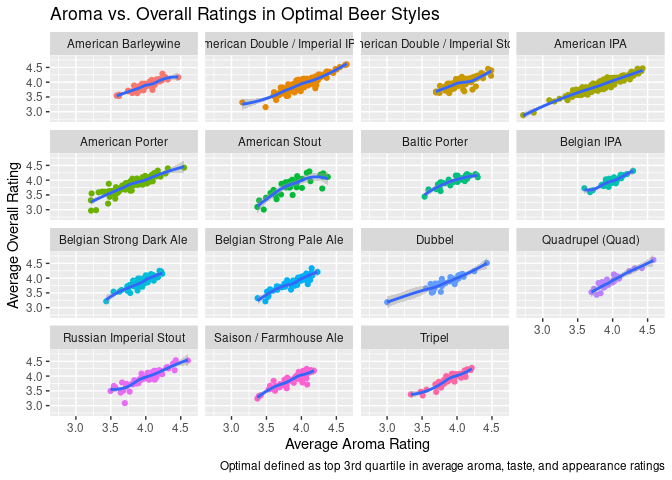

```r
ggplot(data=optimal_styles) +
  geom_point(mapping=aes(y=overall,x=aroma,color=beer_name)) +
  geom_smooth(mapping=aes(y=overall,x=aroma)) +
  theme(legend.position="none") +
  facet_wrap(~beer_name) +
  labs(title="Aroma vs. Overall Ratings in Optimal Beer Styles",x="Average Aroma Rating",y="Average Overall Rating",caption="Optimal defined as top 3rd quartile in average aroma, taste, and appearance ratings")
```

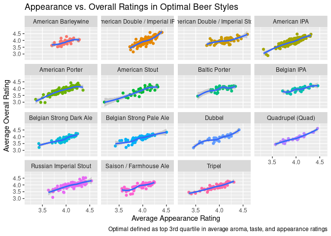

```r
ggplot(data=optimal_styles) +
  geom_point(mapping=aes(y=overall,x=appearance,color=beer_name)) +
  geom_smooth(mapping=aes(y=overall,x=appearance)) +
  theme(legend.position="none") +
  facet_wrap(~beer_name)+
  labs(title="Appearance vs. Overall Ratings in Optimal Beer Styles",x="Average Appearance Rating",y="Average Overall Rating",caption="Optimal defined as top 3rd quartile in average aroma, taste, and appearance ratings")
```

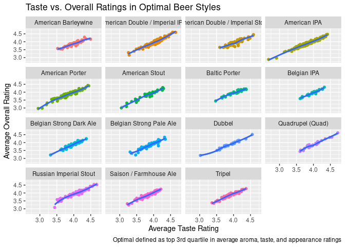

```r
ggplot(data=optimal_styles) +
  geom_point(mapping=aes(y=overall,x=taste,color=beer_name)) +
  geom_smooth(mapping=aes(y=overall,x=taste)) +
  theme(legend.position="none") +
  facet_wrap(~beer_name) +
  labs(title="Taste vs. Overall Ratings in Optimal Beer Styles",x="Average Taste Rating",y="Average Overall Rating",caption="Optimal defined as top 3rd quartile in average aroma, taste, and appearance ratings")
```

These plots can be share with the stakeholders to give them key insights in to how reviewers are going to perceive different beer styles. If they want to optimize the impact of their beers aroma, flavor, and appearance, they should pick from one of these styles.

From there, they could look at these plots to decide which styles might be more optimal than others. For example, the appearance and aroma charts for American Stouts taper off in their overall rating after reaching a certain point. This might tell the brewery owner that it might not be worth their time, effort, and resources to make the most aromatic or dark American Stout possible, as the overall rating will probably not be affected as much.

On the flip side, Dubbel style beers seem to get a noticeable uptick in overall rating when their aroma and appearance go up.

Another interesting insight, however unsurprising, is the strong correlation between taste and overall rating. This tells us that the **taste** of the beer reigns supreme over other factors in deciding it’s overall ratings.

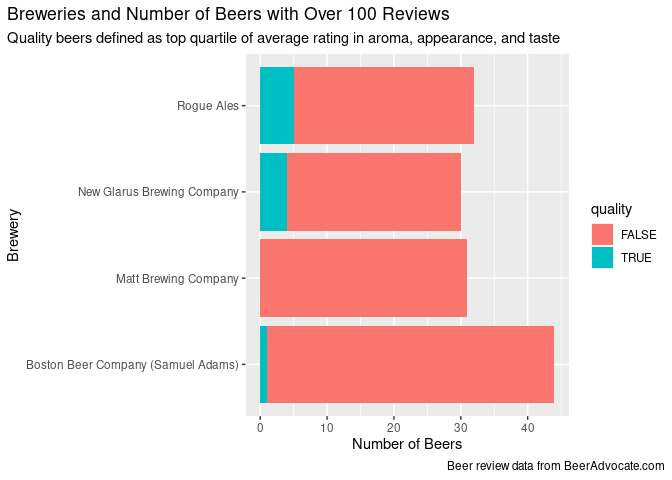

```r
ggplot(data=top_dogs) +
  geom_bar(mapping=aes(y=brewery_name,fill=quality)) +
  theme(plot.title.position = "plot",plot.caption.position = "plot") +
  labs(title="Breweries and Number of Beers with Over 100 Reviews",subtitle="Quality beers defined as top quartile of average rating in aroma, appearance, and taste",x="Number of Beers",y="Brewery",caption="Beer review data from BeerAdvocate.com")
```

This plot will show the stakeholders a little bit of information on the top 4 reviewed breweries that we discovered before. This time, we have created a bar chart with the fill color representing the number of their beers that are either quality or not quality, based on our optimal definition from before of top quartile in aroma, flavor, and appearance.

From this plot, our stakeholders will be able to see which breweries they might want to look more into. We can see that by a pretty good margin that **Sam Adams** is the most reviewed while **Rogue Ales** and **New Glarus** have higher amounts of top quality reviews of their beers.

### 6. Act

In conclusion, the Beer Advocate reviews data, while not perfect, gave us 1.5 million observations to pull insights from, and we were able to answer all of the hypothetical stakeholder questions quite easily. Our suggested actions are to try brewing two new styles of beer, and to visit the top 4 reviewed breweries that we listed.

On top of that, because our data integrity was sub optimal, I would suggest that the business continue the research done here by creating a survey of their own local customers and market, to get a better idea of what their specific customers needs are.

**Thank you for reading!**